# STT 180 (25SP) Homework 1

Araynah Dover

Jan 23 - Feb 7, 2025

**General Instructions:**

- This is an individual assignment. You may consult with others as you work on the assignment, but each student should write up a separate set of solutions.
- Rather than creating a new Rmd file, just add your solutions to the supplied Rmd file. Submit both the Rmd file and the resulting HTML file to D2L.
- Except for questions, or parts of questions, that ask for your commentary, use R in a code chunk to answer the questions.
- The code chunk option **`echo = TRUE`** is specified in the setup code chunk at the beginning of the document. Please do not override this in your code chunks.
- A solution will lose points if the Rmd file does not compile. If one of your code chunks is causing your Rmd file to not compile, you can use the `eval = FALSE` option. Another possibility is to use the `error = TRUE` option in the code chunk.
- This Homework is due on **Friday, Feb 7th, 2025, by 11 pm.**

This homework assignment consists of three sections. The first section deals with data structures and the second section is a small data analysis project. You will use the data wrangling and tidying knowledge for this section.

# Section 1 (30 points)

This section focuses on some basic manipulations of vectors in R.

## Question 1 (6 points)

Create three vectors in R: One called `evennums` which contains the even integers from 1 through 12. One called `charnums` which contains character representations of the numbers 4 through 8, namely, “4”, “5”, “6”, “7”, “8”. And one called `mixed` which contains the same values as in `charnums` but which also contains the letters “x”, “y” and “z”. **No commentary or explanations are necessary.**

```r
evennums <- c(2,4,6,8,10,12)
charnums <- c("4","5","6","7","8")
mixed <- c(2,4,6,8,10,12,"x","y")
```

## Question 2 (6 points)

Investigate what happens when you try to convert `evennums` to character and to logical. - When converting to a char using the as.char method when outputting the list it converted elements to chars and in turn the type is also a char - When converting to logical all values were converted to true being that the ints are greater than 1, Type is logical as well Investigate what happens when you convert `charnums` to numeric. - When converting to numeric tghe output was numeric values as well as the type of list Investigate what happens when you convert `mixed` to numeric. - When converting to numeric for mixed list we got NA values for the chars and num values for ints, the type returned was a double **Comment on each of these conversions.**

```r
# Converting evennums to char
evennums_char <- as.character(evennums)
print(evennums_char)
```

```
[1] "2"  "4"  "6"  "8"  "10" "12"
```

```r
typeof(evennums_char)
```

```
[1] "character"
```

```r
# Converting evennums to log
evennums_logical <- as.logical(evennums)
print(evennums_logical)
```

```
[1] TRUE TRUE TRUE TRUE TRUE TRUE
```

```r
typeof(evennums_logical)
```

```
[1] "logical"
```

```r
# Converting charnums to numeric
charnums_numeric <- as.numeric(charnums)
print(charnums_numeric)
```

```
[1] 4 5 6 7 8
```

```r
typeof(charnums_numeric)
```

```
[1] "double"
```

```r
# Convert mixed to numeric
mixed_numeric <- as.numeric(mixed)
print(mixed_numeric)
```

```
[1]  2  4  6  8 10 12 NA NA
```

```r
typeof(mixed_numeric)
```

```
[1] "double"
```

## Question 3 (10 points)

**No commentary is necessary on this part.**

1. Show how to extract the second element of `evennums.`

```r
even_second <- evennums[2]
even_second
```

```
[1] 4
```

2. Show how to extract the last element of `evennums.` In this case you are NOT allowed to use the fact that `evennums` has six elements, rather, you must give code which would work no matter how many elements `evennums` has.

```r
even_last <- evennums[length(evennums)]
even_last
```

```
[1] 12
```

3. Show how to extract all but the first element of `evennums.`

```r
even_first <- evennums[-1]
even_first
```

```
[1]  4  6  8 10 12
```

4. Show how to extract all but the first two and last two elements of `evennums`.

```r
even_extract <- evennums[3:(length(evennums)-2)]
even_extract
```

```
[1] 6 8
```

5. Calculate the mean of `evennums`. Calculate the standard deviation of the `evennums`.

```r
mean(evennums)
```

```
[1] 7
```

```r
sd(evennums)
```

```
[1] 3.741657
```

## Question 4 (8 points)

Use the help function to find out more about `sd` and ’floor`. **What does the function do?** **What are the arguments?** **Which arguments, if any, are optional?** **Give one simple example using the function.** - `sd`: Gives standard deviation of values in given container, takes a conatiner or range of values and defualt na.rm = FALSE which is optional removes missing values - `floor`:Takes a single numeric argument x and returns a numeric vector containing the largest integers not greater than the corresponding elements of x.

```r
sd(23:85)
```

```
[1] 18.3303
```

```r
floor(5.8)
```

```
[1] 5
```

# Section 2 (30 points)

The dataset contains information about the prices (in USD) of Netflix subscriptions around the world.

## Setting up the data set

Read in the data.

```r
netflix_data <- read.csv("Netflix-subscription-fee-Dec-2021.csv", header = TRUE)
```

## Question 1 (4 points)

Using the `str` function, show how `netflix_data` structured. **What are the variable names? What is the data type of each variable in the data frame?** - Country.Code, Country, Total.Library.Size, Number.of.Tv.Shows, Number, Types range from chars, ints doubles

```r
str(netflix_data)
```

```
'data.frame':   65 obs. of  8 variables:
 $ Country.Code           : chr  "ar" "au" "at" "be" ...
 $ Country                : chr  "Argentina" "Australia" "Austria" "Belgium" ...
 $ Total.Library.Size     : int  4760 6114 5640 4990 4991 4972 6797 6239 4994 4991 ...
 $ Number.of.TV.Shows     : int  3154 4050 3779 3374 3155 3162 4819 4311 3156 3156 ...
 $ Number.of.Movies       : int  1606 2064 1861 1616 1836 1810 1978 1928 1838 1835 ...
 $ Cost.Per.Month.Basic   : num  3.74 7.84 9.03 10.16 7.99 ...
 $ Cost.Per.Month.Standard: num  6.3 12.1 14.7 15.2 11 ...
 $ Cost.Per.Month.Premium : num  9.26 16.39 20.32 20.32 13.99 ...
```

## Question 2 (4 points)

Print out the data from the column called `Cost.Per.Month.Basic`. Show the data type of the data in this column.

```r
per_month = netflix_data$Cost.Per.Month.Basic
per_month
```

```
 [1]  3.74  7.84  9.03 10.16  7.99  4.61  9.03  7.91  7.07  4.31  8.99  9.03
[13]  8.83 12.00  7.99  9.03  9.03 10.16  9.03  9.03  9.03  7.99  7.99  8.08
[25]  7.64  9.03  2.64  8.36  9.03 10.56  9.03  8.73  9.03 12.88  9.03  8.29
[37]  6.62  9.03  9.03  9.03  8.80  9.94  8.29  6.11  7.35  7.13  9.03  9.03
[49]  8.13  9.03  9.51  9.03  6.26  8.07  9.03 10.90 12.88  9.74  8.34  1.97
[61]  5.64  7.91  8.99  8.99  7.99
```

```r
typeof(per_month)
```

```
[1] "double"
```

## Question 3 (4 points)

Print out the data from the column called `Number.of.TV.Shows`. Show the data type of the data in this column.

```r
number_show = netflix_data$Number.of.TV.Shows
number_show
```

```
 [1] 3154 4050 3779 3374 3155 3162 4819 4311 3156 3156 3152 1675 5234 2978 3155
[16] 4486 2638 3604 3814 4079 3344 3154 3154 2883 4802 4426 3718 2449 4515 3650
[31] 3545 3619 4479 1712 4490 3565 3158 2473 3806 3779 4003 2955 3155 3155 4154
[46] 3512 3419 3832 3624 1937 4109 5055 3686 3334 3536 2973 3654 3134 2977 2930
[61] 3261 4551 3826 3154 3154
```

```r
typeof(number_show)
```

```
[1] "integer"
```

## Question 4 (4 points)

Plot the relationship between the number of TV shows available, and the cost of a basic subscription.

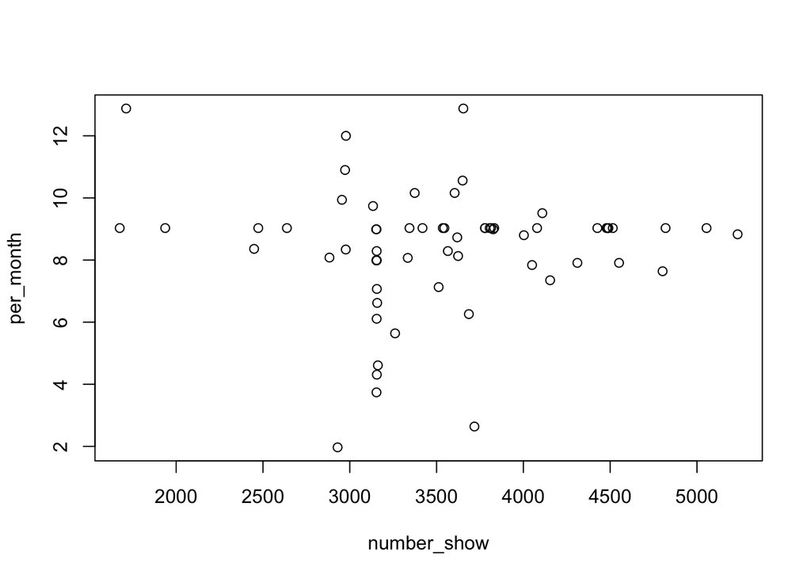

```r
plot(number_show,per_month)
```

## Question 5 (4 points)

**In general does having more TV shows mean paying a higher subscription price? Use the plot from the previous question to justify your answer.**

## Question 6 (6 points)

```r
per_month_basic = netflix_data$Cost.Per.Month.Basic
per_month_premium = netflix_data$Cost.Per.Month.Premium

netflix_data$Upgrade.Cost = per_month_basic / per_month_premium
netflix_data
```

| Country.Code | Country | Total.Library.Size | Number.of.TV.Shows | Number.of.Movies | Cost.Per.Month.Basic | Cost.Per.Month.Standard | Cost.Per.Month.Premium | Upgrade.Cost |
| --- | --- | --- | --- | --- | --- | --- | --- | --- |
| ar | Argentina | 4760 | 3154 | 1606 | 3.74 | 6.30 | 9.26 | 0.4038877 |
| au | Australia | 6114 | 4050 | 2064 | 7.84 | 12.12 | 16.39 | 0.4783405 |
| at | Austria | 5640 | 3779 | 1861 | 9.03 | 14.67 | 20.32 | 0.4443898 |
| be | Belgium | 4990 | 3374 | 1616 | 10.16 | 15.24 | 20.32 | 0.5000000 |
| bo | Bolivia | 4991 | 3155 | 1836 | 7.99 | 10.99 | 13.99 | 0.5711222 |
| br | Brazil | 4972 | 3162 | 1810 | 4.61 | 7.11 | 9.96 | 0.4628514 |
| bg | Bulgaria | 6797 | 4819 | 1978 | 9.03 | 11.29 | 13.54 | 0.6669129 |
| ca | Canada | 6239 | 4311 | 1928 | 7.91 | 11.87 | 15.03 | 0.5262808 |
| cl | Chile | 4994 | 3156 | 1838 | 7.07 | 9.91 | 12.74 | 0.5549451 |
| co | Colombia | 4991 | 3156 | 1835 | 4.31 | 6.86 | 9.93 | 0.4340383 |

[output cut: 55 more lines]

## Question 7 (4 points)

Which country has the highest upgrade cost, according to your new column? Show how you found you answer using code.

```r
max_upgrade <- max(netflix_data$Upgrade.Cost)

max_pos <- which.max(netflix_data$Upgrade.Cost)

max_country = netflix_data$Country[max_pos]

max_country
```

```
[1] "Taiwan"
```

```r
max_upgrade
```

```
[1] 0.692253
```

# Section 3 (30 points)

A more accurate way of determining “how much” people pay for Netflix around the world would be to compare subscription prices with median incomes for each country. We will do that in this section.

## Question 1 (2 points)

Read the data into a variable called `income_data`, from the file, `median-income-by-country.csv`.

```r
income_data <- read.csv("median-income-by-country.csv")
income_data
```

| country | medianIncome | meanIncome | gdpPerCapitaPPP | pop2021 |
| --- | --- | --- | --- | --- |
| Luxembourg | 26321 | 31376 | 124590 | 634814 |
| United Arab Emirates | 24292 | 27017 | 70089 | 9991089 |
| Norway | 22684 | 25272 | 70005 | 5465630 |
| Switzerland | 21490 | 25787 | 72376 | 8715494 |
| United States | 19306 | 25332 | 65297 | 332915073 |
| Canada | 18652 | 22042 | 51668 | 38067903 |
| Austria | 18405 | 20718 | 60418 | 9043070 |
| Sweden | 17625 | 20193 | 56632 | 10160169 |
| Denmark | 17432 | 20304 | 62089 | 5813298 |
| Netherlands | 17154 | 19690 | 61285 | 17173099 |

[output cut: 152 more lines]

## Question 2 (4 points)

How many countries are represented in the `income_data` data frame? How does this compare to the number of countries represented in the `netflix_data` data frame? **What issues do you think could come up if you try to combine information from the two data frames?**

```r
len_country = length(unique(income_data$country))
len_country
```

```
[1] 162
```

## Question 3 (8 points)

Create a new column in the `netflix_data` data frame and name it `median_income`. It should contain the median income for each country in the `netflix_data` data frame. (Some countries from `netflix_data` might not be represented in `income_data`, which makes it impossible to get the median income data for these countries. This is okay, and you can leave these data points as `NA`.) Hint: use the `match` function.

```r
match_country = match(netflix_data$Country, income_data$country)

netflix_data$median_income <- income_data$medianIncome[match_country]
netflix_data
```

| Country.Code | Country | Total.Library.Size | Number.of.TV.Shows | Number.of.Movies | Cost.Per.Month.Basic | Cost.Per.Month.Standard | Cost.Per.Month.Premium | Upgrade.Cost | median_income |
| --- | --- | --- | --- | --- | --- | --- | --- | --- | --- |
| ar | Argentina | 4760 | 3154 | 1606 | 3.74 | 6.30 | 9.26 | 0.4038877 | 5319 |
| au | Australia | 6114 | 4050 | 2064 | 7.84 | 12.12 | 16.39 | 0.4783405 | 17076 |
| at | Austria | 5640 | 3779 | 1861 | 9.03 | 14.67 | 20.32 | 0.4443898 | 18405 |
| be | Belgium | 4990 | 3374 | 1616 | 10.16 | 15.24 | 20.32 | 0.5000000 | 16157 |
| bo | Bolivia | 4991 | 3155 | 1836 | 7.99 | 10.99 | 13.99 | 0.5711222 | 3631 |
| br | Brazil | 4972 | 3162 | 1810 | 4.61 | 7.11 | 9.96 | 0.4628514 | 4559 |
| bg | Bulgaria | 6797 | 4819 | 1978 | 9.03 | 11.29 | 13.54 | 0.6669129 | 5696 |
| ca | Canada | 6239 | 4311 | 1928 | 7.91 | 11.87 | 15.03 | 0.5262808 | 18652 |
| cl | Chile | 4994 | 3156 | 1838 | 7.07 | 9.91 | 12.74 | 0.5549451 | 6293 |
| co | Colombia | 4991 | 3156 | 1835 | 4.31 | 6.86 | 9.93 | 0.4340383 | 3259 |

[output cut: 55 more lines]

## Question 4 (4 points)

Make a plot of the relationship between median income and basic subscription prices for Netflix. Hint: In the `plot` function, use the `rm.na` argument.

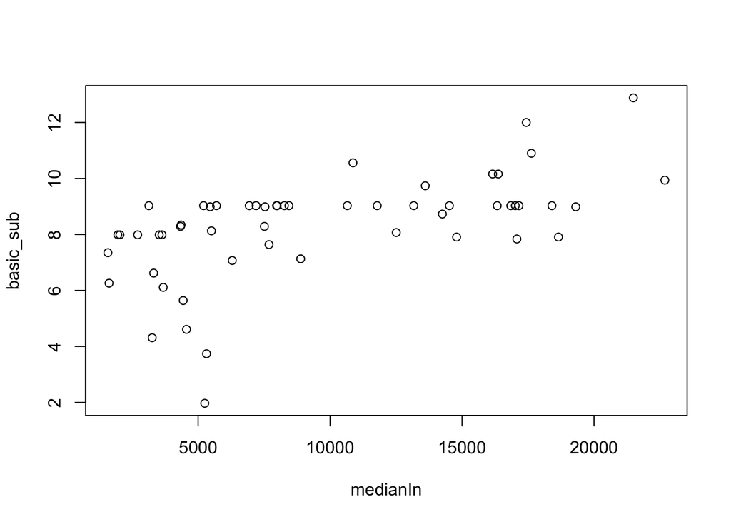

```r
medianIn = netflix_data$median_income
basic_sub = netflix_data$Cost.Per.Month.Basic

plot(medianIn,basic_sub, rm.na=TRUE)
```

## Question 5 (4 points)

**In general do people in countries with a higher median income have to pay a higher subscription price? Use the plot from the previous question to justify your answer.**

- Based on the plot it is seen that the higher the median price the greater the basic subscription

## Question 6 (4 points)

Create a new column called `Basic.Cost.Per.Show`, which represents the basic subscription cost *per* TV show. Which country has the highest cost per show?

```r
netflix_data$Basic.Cost.Per.Show <- netflix_data$Cost.Per.Month.Basic / netflix_data$Number.of.TV.Shows

max_pershow <- max(netflix_data$Basic.Cost.Per.Show)

max_pos <- which.max(netflix_data$Basic.Cost.Per.Show)

max_country = netflix_data$Country[max_pos]

max_country
```

```
[1] "Liechtenstein"
```

```r
max_pershow
```

```
[1] 0.007523364
```

## Question 7 (4 points)

Which country has the highest cost per show, after you take into account median income?

```r
netflix_data <- netflix_data[!is.na(netflix_data$Basic.Cost.Per.Show) & !is.na(netflix_data$median_income), ]

netflix_data$Adjusted.Basic.Cost.Per.Show <- netflix_data$Basic.Cost.Per.Show / netflix_data$median_income

max_pershow <- max(netflix_data$Adjusted.Basic.Cost.Per.Show)

max_pos <- which.max(netflix_data$Adjusted.Basic.Cost.Per.Show)

max_country = netflix_data$Country[max_pos]

max_country
```

```
[1] "Honduras"
```

```r
max_pershow
```

```
[1] 1.293155e-06
```

# Essential details

### Deadline and submission

- The deadline to submit Homework 1 is **11:00pm on Friday, Feb 7th, 2025.** This is a individual assignment.
- Submit your work by uploading your RMD and HTML/PDF files through D2L. Kindly **double check your submission to note whether the everything is displayed in the uploaded version of the output in D2L or not.** If submitting HTML outputs, please zip the .rmd and html files for submission.
- Please enable the **`echo=TRUE`** option in your code chunks and name each code chunk.
- **Late work will not be accepted except under certain extraordinary circumstances.**

### Help

- If you are trying to get help on a code error, explain your error in detail.
- Feel free to visit us in during our virtual office hours or make an appointment.
- Communicate with your classmates, but do not share snippets of code.
- Start the assignment early. **If you wait until the last minute to start and try to ask questions the night the assignment is due, we cannot guarantee a timely response.**

### Academic integrity

This is an individual assignment. You may discuss ideas, how to debug code, and how to approach a problem with your classmates. You may not copy-and-paste another’s code from this class or copy answers directly from an AI tool (example: ChatGPT). As a reminder, below is the policy on sharing and using other’s code.

> Similar reproducible examples (reprex) exist online that will help you answer many of the questions posed on group assignments, and homework assignments. Use of these resources is allowed unless it is written explicitly on the assignment. While you may use AI tools to help debug code or understand a topic, you may not use it to answer assignment questions for you. You must ALWAYS cite any code you copy or use as inspiration. Copied code without citation is plagiarism and will result in a 0 for the assignment.

### Grading

You must use R Markdown. Formatting is at your discretion but is graded. Use the in-class assignments and resources available online for inspiration. Another useful resource for R Markdown formatting is available at: https://holtzy.github.io/Pimp-my-rmd/

| **Topic** | **Points** |
| --- | --- |
| Section 1 | 30 |
| Section 2 | 30 |
| Section 3 | 30 |
| Code style and R Markdown formatting | 5 |
| Rmd file compilation | 5 |
| ——— | ———-: |
| Total | 100 |